# PROJET: tuberculose

À partir de 4 clusters, la diminution de l’inertie devient très marginale, ce qui signifie que l’ajout de nouveaux clusters n’améliore plus de manière significative la séparation entre les groupes. Cela est en accord avec les résultats observés pour l’ensemble de la période 1990-2013.

Cependant, l’inertie continue de diminuer entre 2 et 3 clusters, mais la décroissance est légèrement plus marquée dans l’ensemble des années 1990 à 2013 que pour l’année 2000 seule. Cela pourrait refléter des dynamiques temporelles plus complexes et une plus grande hétérogénéité dans les données au cours de cette période étendue.

En revanche, la diminution de l’inertie après 4 clusters reste marginale dans les deux cas (année 2000 et période 1990-2013). Cela montre que les ajouts de clusters au-delà de 4 n’apportent que peu d’améliorations significatives.

Ainsi, en comparant les deux diagrammes, on constate que le nombre optimal de clusters reste 4 tant pour l’année 2000 que pour la période de 1990 à 2013. Cela montre une similarité dans la structure des groupes entre ces deux périodes. Par conséquent, l’ajout de clusters au-delà de 4 ne semble pas apporter d’amélioration significative, que ce soit pour l’année 2000 ou pour l’ensemble de la période étudiée.

Nous allons maintenant examiner les plans par individus et les arbres hiérarchiques pour les classes de 1 à 4, car au-delà de 4, l’ajout de nouveaux clusters n’améliore plus significativement la séparation des groupes. Tout d’abord, nous allons créer les étiquettes des clusters en utilisant la méthode de Ward pour le clustering hiérarchique. Nous appliquons la fonction cutree sur l’objet tb.clust2, qui contient le résultat du clustering hiérarchique effectué avec la méthode de Ward. Nous définissons les clusters avec 2, 3 et 4 groupes, et stockons les résultats dans les variables labels2_2, labels3_2 et labels4_2:

```r
labels2_2 <- cutree(tb.clust2, k = 2)
labels3_2 <- cutree(tb.clust2, k = 3)
labels4_2 <- cutree(tb.clust2, k = 4)
```

Ensuite, nous créons un nouveau tableau TB2_ACP_comparaison2 qui contient les données des colonnes 3 à 7 de TB2_ACP_comparaison, ainsi que les étiquettes des clusters obtenues pour 2, 3 et 4 groupes. Nous convertissons les labels en caractères afin de pouvoir les utiliser dans l’ACP:

```r
TB2_ACP_comparaison2<- as.data.frame(cbind(TB2_ACP_comparaison[,3:7],labels2_2, labels3_2, labels4_2) )
TB2_ACP_comparaison2[,6]= as.character(TB2_ACP_comparaison2[,6])
TB2_ACP_comparaison2[,7]= as.character(TB2_ACP_comparaison2[,7])
TB2_ACP_comparaison2[,8]= as.character(TB2_ACP_comparaison2[,8])
```

Enfin, nous réalisons l’ACP sur ce tableau enrichi, en spécifiant les variables qualitatives supplémentaires (les labels des clusters). Nous appliquons la standardisation des données avec scale.unit = TRUE, et nous choisissons de ne pas afficher les graphiques avec graph = FALSE:

```r
res.pca.comparaison <- PCA(TB2_ACP_comparaison2, quali.sup=c(6,7,8), scale.unit= TRUE,graph = FALSE)
```

Comparaison des visualisations des clusters sur CP1-CP2 : 2 classes

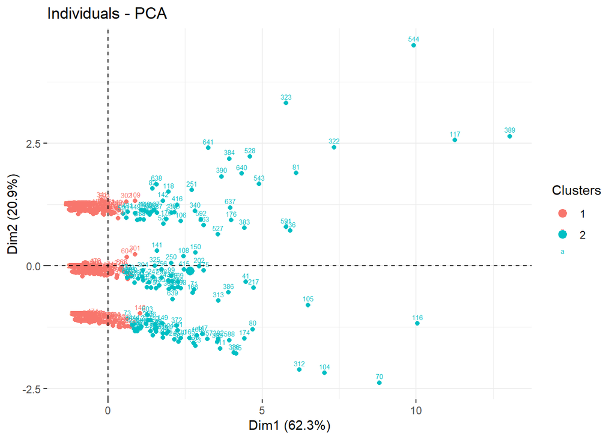

```r
fviz_pca_ind(res.pca.comparaison, # Utilisation des résultats de PCA précédemment calculés

             geom.ind = c("point", "text"), # Affichage des points et des étiquettes (noms des individus) sur le graphique

             labelsize = 2,  # Taille de la police pour les étiquettes des individus

             col.ind =TB2_ACP_comparaison2$labels2_2,
              pointshape = 19,
             legend.title = "Clusters")
```

On compare des années dans le plan des individus :

La ligne du bas (1990) correspond à l’année 1990. Les individus de cette année sont répartis sur l’axe Dim1 (horizontal), mais on remarque aussi que les points rouges (classe 1) sont regroupés à gauche, tandis que les points bleus (classe 2) sont davantage à droite, sur l’axe Dim1. L’axe Dim2 (vertical) présente une certaine dispersion des points à cette période, mais il semble que la séparation sur Dim1 est la plus marquée.

Les individus de l’année 2000 (ligne du milieu) montrent une séparation encore plus nette sur Dim1. Les points de la classe 1 (rouge) sont principalement concentrés autour de l’origine de Dim1, tandis que les points de la classe 2 (bleu) se déplacent plus à droite sur cet axe. Dim2 semble avoir une moins grande influence sur la séparation des classes à cette époque.